# TheTitanic_GroupNotebook_1490804_1653288

## The Titanic -- Machine Learning from Disaster

### Contributors:

#### Nduvho Ramashia -- 1490804 -- https://www.kaggle.com/nduvhoedward

#### Muchaveleli Manjate -- 1653288

This objective of the competition is to predict if specific titanic passangers survived the tragic titanic incident. The aim is to construct and train a model given a train dataset that has the passengers' details, including whether or not they survived. Once the model has been trained, it is to tested using the test data, a dataset without the passengers' survival details. This is then submitted to kaggle for rating.

The already privided features will be examined, their correlations observed, amongst other analysis. To amplify some correlations, some features will be created as well.

Different machine learning will be implemented. They then will be tested and observed, to find the better perfoming ones and their optimum parameters and featers. The best model will then be used to make the final training and testing on the test data which will then be submitted to kaggle.

```python
import numpy as np # linear algebra
import pandas as pd # data processing, CSV file I/O (e.g. pd.read_csv)
import seaborn as sns
import matplotlib.pyplot as plt
from sklearn.model_selection import cross_val_score
from sklearn.naive_bayes import GaussianNB
from sklearn.linear_model import LogisticRegression
from sklearn import tree
from sklearn.neighbors import KNeighborsClassifier
from sklearn.ensemble import RandomForestClassifier
from sklearn.svm import SVC
from sklearn.model_selection import GridSearchCV
from sklearn.model_selection import RandomizedSearchCV
from sklearn.metrics import mean_absolute_error, r2_score, mean_squared_error, accuracy_score, classification_report, confusion_matrix, precision_score, recall_score

from sklearn import preprocessing
l_encoder = preprocessing.LabelEncoder()
import sklearn
import matplotlib as mpl
import matplotlib.pyplot as plt
#from sklearn import *
from sklearn.linear_model import LogisticRegression
from sklearn.metrics import mean_absolute_error
from scipy.optimize import minimize
from sklearn.preprocessing import PolynomialFeatures
from sklearn.model_selection import train_test_split
from sklearn.model_selection import GridSearchCV
from sklearn.feature_selection import RFECV
from sklearn.model_selection import RandomizedSearchCV
from sklearn import pipeline
from sklearn.pipeline import Pipeline
from sklearn.preprocessing import StandardScaler

pd.set_option('display.max_columns', None)
pd.set_option('display.max_rows', 150)
pd.set_option('display.max_seq_items', None)

%matplotlib inline

sns.set_context('notebook')
sns.set_style('white')
```

## K-Nearest Neighbors & Naiive Bayes Classifier

### Data Cleaning and Understanding

```python
train_data = pd.read_csv("./Data/train.csv")
test_data = pd.read_csv("./Data/test.csv")
subm_exampl = pd.read_csv("./Data/gender_submission.csv")
all_data = train_data.append(test_data) #For simplified cleaning
```

```python
all_data.head(2)
```

|  | PassengerId | Survived | Pclass | Name | Sex | Age | SibSp | Parch | Ticket | Fare | Cabin | Embarked |
| --- | --- | --- | --- | --- | --- | --- | --- | --- | --- | --- | --- | --- |
| 0 | 1 | 0.0 | 3 | Braund, Mr. Owen Harris | male | 22.0 | 1 | 0 | A/5 21171 | 7.2500 | NaN | S |
| 1 | 2 | 1.0 | 1 | Cumings, Mrs. John Bradley (Florence Briggs Th... | female | 38.0 | 1 | 0 | PC 17599 | 71.2833 | C85 | C |

```python
all_data.tail(3)
```

|  | PassengerId | Survived | Pclass | Name | Sex | Age | SibSp | Parch | Ticket | Fare | Cabin | Embarked |
| --- | --- | --- | --- | --- | --- | --- | --- | --- | --- | --- | --- | --- |
| 415 | 1307 | NaN | 3 | Saether, Mr. Simon Sivertsen | male | 38.5 | 0 | 0 | SOTON/O.Q. 3101262 | 7.2500 | NaN | S |
| 416 | 1308 | NaN | 3 | Ware, Mr. Frederick | male | NaN | 0 | 0 | 359309 | 8.0500 | NaN | S |
| 417 | 1309 | NaN | 3 | Peter, Master. Michael J | male | NaN | 1 | 1 | 2668 | 22.3583 | NaN | C |

#### Cleaning

```python
train_data.info()
```

```
<class 'pandas.core.frame.DataFrame'>
RangeIndex: 891 entries, 0 to 890
Data columns (total 12 columns):
 #   Column       Non-Null Count  Dtype
---  ------       --------------  -----
 0   PassengerId  891 non-null    int64
 1   Survived     891 non-null    int64
 2   Pclass       891 non-null    int64
 3   Name         891 non-null    object
 4   Sex          891 non-null    object
 5   Age          714 non-null    float64
 6   SibSp        891 non-null    int64
 7   Parch        891 non-null    int64
 8   Ticket       891 non-null    object
 9   Fare         891 non-null    float64
 10  Cabin        204 non-null    object
 11  Embarked     889 non-null    object
dtypes: float64(2), int64(5), object(5)
memory usage: 83.7+ KB
```

```python
meanAge=np.mean(all_data['Age'])
all_data['Age']=all_data['Age'].fillna(meanAge)
meanFare=np.mean(all_data['Fare'])
all_data['Fare']=all_data['Fare'].fillna(meanAge)
```

The passenger's relatives-state/feature is already considered by the 'family_size' feture, so the only yet usable information from the passanger's title. Pressumably military personel stand a better survival chance than personels who work indoors. As such, a new feature is created, named "Name_Title", after with the "Name" feature is removed

```python
all_data['Name_title'] = all_data.Name.apply(lambda x: x.split(',')[1].split('.')[0].strip())
#Dropping presumably irrelevant features
all_data.drop(['Name','Ticket','PassengerId'], inplace=True, axis=1)
```

```python
# The NaN rows on Survived, from the test data, is filled with 1's, initially, optimistic much.
# The states, which were changed to floats is changed back to descrete integers.
all_data['Survived']=all_data['Survived'].fillna(1)
all_data = all_data.astype({'Survived':'int'})
```

At this point, there are still 2 features with NaNs, those being Cabin and Embarked. The group of people with no cabin assigned to them are assumed to have been on the same general cabin catagory, named here 'other'. The 2 passengers with no indication of where they embarked are assumed to be the ship's personel, and assumed to have embarked from where the ship first took off.

```python
all_data['Cabin'] = all_data['Cabin'].fillna('Other')
all_data['Embarked'] = all_data['Embarked'].fillna('S')
```

There could be some relationship between the fetures sex, cabin, the place a passenger embarked, as well as the passengers title, and the passenger's survival. To better analyse these, the relevent data columns are converted/encorded into numberic values.

```python
all_data['Sex'] = l_encoder.fit_transform(all_data['Sex'])
all_data['Cabin'] = l_encoder.fit_transform(all_data['Cabin'])
all_data['Embarked'] = l_encoder.fit_transform(all_data['Embarked'])
all_data['Name_title'] = l_encoder.fit_transform(all_data['Name_title'])
```

```python
#Creating new family_size column
all_data['Family_Size']=all_data['SibSp']+all_data['Parch']
all_data['Age*Class']=all_data['Age']*all_data['Pclass']
```

```python
all_data.head(2)
```

|  | Survived | Pclass | Sex | Age | SibSp | Parch | Fare | Cabin | Embarked | Name_title | Family_Size | Age*Class |
| --- | --- | --- | --- | --- | --- | --- | --- | --- | --- | --- | --- | --- |
| 0 | 0 | 3 | 1 | 22.0 | 1 | 0 | 7.2500 | 185 | 2 | 12 | 1 | 66.0 |
| 1 | 1 | 1 | 0 | 38.0 | 1 | 0 | 71.2833 | 106 | 0 | 13 | 1 | 38.0 |

```python
train_clean = all_data[0:891]
test_clean = all_data[891:1309]
test_clean.drop(['Survived'], inplace=True, axis=1)
```

#### Analysing

```python
import matplotlib.pyplot as plt
%matplotlib inline
```

```python
# Plot and figure parameters
plt.rcParams.update({'font.size':20,'figure.figsize':(10,8)})
```

To have a rough idea about what features are related, more specifically what features are related to the 'Survived' feature, a heatmap if used.

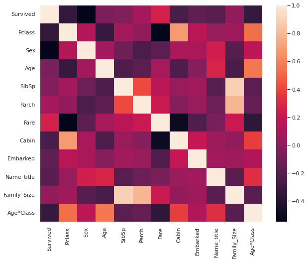

```python
sns.heatmap(train_clean.corr(),annot=False)
```

```python
pd.pivot_table(train_clean,index='Survived',columns='Parch', values = 'Fare', aggfunc='count')
```

| Parch Survived | 0 | 1 | 2 | 3 | 4 | 5 | 6 |
| --- | --- | --- | --- | --- | --- | --- | --- |
| 0 | 445.0 | 53.0 | 40.0 | 2.0 | 4.0 | 4.0 | 1.0 |
| 1 | 233.0 | 65.0 | 40.0 | 3.0 | NaN | 1.0 | NaN |

```python
pd.pivot_table(train_clean,index='Survived',columns='Family_Size', values = 'Fare', aggfunc='count')
```

| Family_Size Survived | 0 | 1 | 2 | 3 | 4 | 5 | 6 | 7 | 10 |
| --- | --- | --- | --- | --- | --- | --- | --- | --- | --- |
| 0 | 374.0 | 72.0 | 43.0 | 8.0 | 12.0 | 19.0 | 8.0 | 6.0 | 7.0 |
| 1 | 163.0 | 89.0 | 59.0 | 21.0 | 3.0 | 3.0 | 4.0 | NaN | NaN |

```python
pd.pivot_table(train_clean, index = 'Survived', values = ['Age','SibSp','Parch','Fare'])
```

| Survived | Age | Fare | Parch | SibSp |
| --- | --- | --- | --- | --- |
| 0 | 30.456543 | 22.117887 | 0.329690 | 0.553734 |
| 1 | 28.577454 | 48.395408 | 0.464912 | 0.473684 |

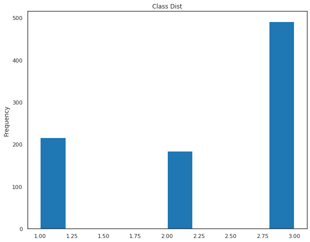

```python
train_data['Pclass'].plot(kind='hist',title='Class Dist')
```

### Modelling

```python
X = train_clean[['Pclass','Sex','Age','SibSp','Parch','Fare','Cabin','Embarked','Family_Size','Age*Class','Name_title']]
y = train_clean[['Survived']]
```

```python
train_clean.head(2)
```

|  | Survived | Pclass | Sex | Age | SibSp | Parch | Fare | Cabin | Embarked | Name_title | Family_Size | Age*Class |
| --- | --- | --- | --- | --- | --- | --- | --- | --- | --- | --- | --- | --- |
| 0 | 0 | 3 | 1 | 22.0 | 1 | 0 | 7.2500 | 185 | 2 | 12 | 1 | 66.0 |
| 1 | 1 | 1 | 0 | 38.0 | 1 | 0 | 71.2833 | 106 | 0 | 13 | 1 | 38.0 |

```python
from sklearn.model_selection import train_test_split
X_train, X_test, y_train, y_test = train_test_split(X, y, test_size=0.25, random_state=14)
```

```python
#simple performance reporting function
def clf_performance(classifier, model_name):
    print(model_name)
    print('Best Score: ' + str(classifier.best_score_))
    print('Best Parameters: ' + str(classifier.best_params_))
```

Samples that will be used during the experiments. After which to better performing model will be used for the final submission model

#### Neive Bayes

```python
gnb = GaussianNB()
param_grid = [{'var_smoothing': np.logspace(0,-10, num=20)}]
clf_gnb = GridSearchCV(gnb, param_grid = param_grid, cv = 10, verbose = True, n_jobs = -1)

best_clf_gnb = clf_gnb.fit(X_train,y_train.values.ravel())
clf_performance(best_clf_gnb,'gnb')
```

```
Fitting 10 folds for each of 20 candidates, totalling 200 fits
gnb
Best Score: 0.7739936680235188
Best Parameters: {'var_smoothing': 4.832930238571752e-07}
```

#### KNN

```python
knn = KNeighborsClassifier()
param_grid = {'n_neighbors' : [3,4,5,6,7,8,9,10,11,12,13,14,15,16,17],
              'weights' : ['uniform', 'distance'],
              'algorithm' : ['auto', 'ball_tree','kd_tree'],
              'p' : [1,2]}
clf_knn = GridSearchCV(knn, param_grid = param_grid, cv = 5, verbose = True, n_jobs = -1)
best_clf_knn = clf_knn.fit(X_train,y_train.values.ravel())
clf_performance(best_clf_knn,'KNN')
```

```
Fitting 5 folds for each of 180 candidates, totalling 900 fits
KNN
Best Score: 0.7649983166872405
Best Parameters: {'algorithm': 'auto', 'n_neighbors': 9, 'p': 1, 'weights': 'distance'}
```

#### Experimenting

```python
#Different(ALL) combinations of features to be used by the model
from itertools import combinations
sample_list = cols = ['Pclass','Sex','Age','SibSp',
                      'Parch','Fare','Cabin','Embarked',
                      'Family_Size','Age*Class','Name_title']
list_combinations = list()
for n in range(len(sample_list) + 1):
    list_combinations += list(combinations(sample_list, n))

# Initializing desired taples lengths
i, j = 5, 12
# Filter Range Length Tuples
temp = list(filter(lambda ele: len(ele) >= i and len(ele) <= j, list_combinations))
list_combinations = temp[0:50] # Experimenting with only the first few variations
len(list_combinations)
```

```
50
```

```python
def model_outcomes(ml_name,model, y_test, pred, features):
    acc = round(model.best_score_*100,5)
    pres = round(precision_score(y_test,pred)*100,5)
    recall = round(recall_score(y_test,pred)*100,5)
    best_par = model.best_params_
    mae = round(mean_absolute_error(y_test,pred)*100,5)
    mse = round(mean_squared_error(y_test,pred)*100,5)

    df = pd.DataFrame({"Alg":[ml_name],
                     "Accuracy":[acc],
                     "Mean Absolute Error":[mae],
                     "Mean Square Error":[mse],
                     "Precision":[pres],
                     "Recall":[recall],
                     "Best Params:":[best_par],
                     "Features:":[features]})
    return df
```

```python
# Testing the 2 algorithms with different features
def features_testing(train_clean, list_combinations):
    # Creating the first Dataframe to store different properties of different testing scenarios
    exper_results = pd.DataFrame({"Alg":[],
                         "Accuracy":[],
                         "Mean Absolute Error":[],
                         "Mean Square Error":[],
                         "Precision":[],
                         "Recall":[],
                         "Best Params:":[],
                         "Features:":[]})

    # Testing different sets of features
    for features in list_combinations:
        X = train_clean[list(features)]
        y = train_clean[['Survived']]
        X_train, X_test, y_train, y_test = train_test_split(X, y, test_size=0.25, random_state=14)

        # Naiive Bayes
        gnb = GaussianNB()
        param_grid = [{'var_smoothing': np.logspace(0,-10, num=10)}]
        clf_gnb = GridSearchCV(gnb, param_grid = param_grid, cv = 5, verbose = False, n_jobs = -1)
        best_clf_gnb = clf_gnb.fit(X_train,y_train.values.ravel())
        # - testing
        pred = best_clf_gnb.best_estimator_.predict(X_test)
        temp = model_outcomes('nbc',best_clf_gnb, y_test, pred,features)
        exper_results = exper_results.append(temp, ignore_index = True)

        # KNeighborsClassifier
        knn = KNeighborsClassifier()
        param_grid = {'n_neighbors' : [3,5,6,7,8,9,10,11,12,13,14,15,16,17],
                      'weights' : ['uniform', 'distance'],
                      'algorithm' : ['auto', 'ball_tree','kd_tree'],
                      'p' : [1,2]}
        clf_knn = GridSearchCV(knn, param_grid = param_grid, cv = 5, verbose = True, n_jobs = -1)
        best_clf_knn = clf_knn.fit(X_train,y_train.values.ravel())
        # - testing
        pred = best_clf_knn.best_estimator_.predict(X_test)
        temp = model_outcomes('knn',best_clf_knn, y_test, pred,features)
        exper_results = exper_results.append(temp, ignore_index = True)

    return exper_results
```

```python
experiments = features_testing(train_clean, list_combinations)
```

```python
experiments.shape
```

```
(100, 8)
```

```python
max_accuracy = experiments['Accuracy'].max()
max_row = experiments[experiments['Accuracy']==max_accuracy]
max_row
```

|  | Alg | Accuracy | Mean Absolute Error | Mean Square Error | Precision | Recall | Best Params: | Features: |
| --- | --- | --- | --- | --- | --- | --- | --- | --- |
| 91 | knn | 82.18382 | 15.69507 | 15.69507 | 90.16393 | 65.47619 | {'algorithm': 'ball_tree', 'n_neighbors': 14, ... | ('Pclass', 'Sex', 'SibSp', 'Embarked', 'Name_t... |

#### The final Model using the best features and parameters

```python
# The best model, features and parameters
features = ('Pclass', 'Sex', 'SibSp', 'Embarked', 'Name_title')
X = train_clean[list(features)]
y = train_clean[['Survived']]
X_train, X_test, y_train, y_test = train_test_split(X, y, test_size=0.30, random_state=14)

param_grid = {'n_neighbors' : [14],
              'weights' : ['uniform'],
              'algorithm' : ['ball_tree'],
              'p' : [1]}
clf_knn = GridSearchCV(knn, param_grid = param_grid, cv = 5, verbose = True, n_jobs = -1)
best_clf_knn = clf_knn.fit(X,y.values.ravel()) #Finally training with the whole training set
```

```
Fitting 5 folds for each of 1 candidates, totalling 5 fits
```

```python
# Doing the predictions on the test data
test_clean = test_clean[list(features)]
predictions = best_clf_knn.best_estimator_.predict(test_clean)
```

```python
subm = pd.DataFrame(test_data['PassengerId'])
subm['Survived'] = predictions
```

```python
subm.tail(3)
```

|  | PassengerId | Survived |
| --- | --- | --- |
| 415 | 1307 | 0 |
| 416 | 1308 | 0 |
| 417 | 1309 | 1 |

```python
subm.to_csv("submission3.csv", index = False)
```

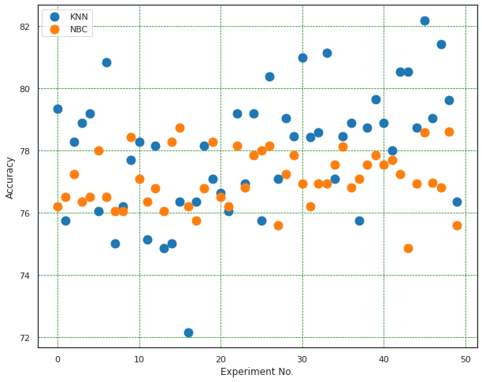

```python
x = np.arange(50)
nbc_exps = experiments[experiments['Alg']=='nbc']
knn_exps = experiments[experiments['Alg']=='knn']
knn_accur = knn_exps['Accuracy']
nbc_accur = nbc_exps['Accuracy']

plt.scatter(x,knn_accur,s=120,label='ideal')
plt.scatter(x,nbc_accur,s=120,label='noisy')
plt.xlabel('Experiment No.')
plt.ylabel('Accuracy')


plt.grid(color = 'green', linestyle = '--', linewidth = 0.7)
plt.legend(["KNN", "NBC"])
```

The KNN has a better trend than the NBC based model. It has greater chance of perfoming better than the NBC model, as can be seen on the figure above.

[figure not shown]

```python
knn_er = knn_exps['Mean Absolute Error']
nbc_er = nbc_exps['Mean Absolute Error']

plt.scatter(x,knn_er,s=120, color='red')
plt.scatter(x,nbc_er,s=120, color='blue')

plt.xlabel('Experiment No.')
plt.ylabel('Mean Error')


plt.grid(color = 'green', linestyle = '--', linewidth = 0.7)
plt.legend(["KNN_MSE", "NBC_MSE", "KNN_MAE", "NBC_MAE"])
```

The error trends are not definitive. While the KNN has the lowest errors, it also has some of the highest errors

## Logistic Regression

```python
# read the data and prepare features
survivor_data = pd.read_csv("./Data/train.csv")
survivor_data = survivor_data.dropna(axis=0)
prediction_target = survivor_data.Survived
Y = prediction_target
actual_survivors = pd.read_csv("./Data/test.csv")
# print a summary of the data
survivor_data.describe()
```

|  | PassengerId | Survived | Pclass | Age | SibSp | Parch | Fare |
| --- | --- | --- | --- | --- | --- | --- | --- |
| count | 183.000000 | 183.000000 | 183.000000 | 183.000000 | 183.000000 | 183.000000 | 183.000000 |
| mean | 455.366120 | 0.672131 | 1.191257 | 35.674426 | 0.464481 | 0.475410 | 78.682469 |
| std | 247.052476 | 0.470725 | 0.515187 | 15.643866 | 0.644159 | 0.754617 | 76.347843 |
| min | 2.000000 | 0.000000 | 1.000000 | 0.920000 | 0.000000 | 0.000000 | 0.000000 |
| 25% | 263.500000 | 0.000000 | 1.000000 | 24.000000 | 0.000000 | 0.000000 | 29.700000 |
| 50% | 457.000000 | 1.000000 | 1.000000 | 36.000000 | 0.000000 | 0.000000 | 57.000000 |
| 75% | 676.000000 | 1.000000 | 1.000000 | 47.500000 | 1.000000 | 1.000000 | 90.000000 |
| max | 890.000000 | 1.000000 | 3.000000 | 80.000000 | 3.000000 | 4.000000 | 512.329200 |

```python
survivor_data.columns
```

```
Index(['PassengerId', 'Survived', 'Pclass', 'Name', 'Sex', 'Age', 'SibSp',
       'Parch', 'Ticket', 'Fare', 'Cabin', 'Embarked'],
      dtype='object')
```

```python
survivor_features =['Age','Pclass','PassengerId','Parch','Fare']
#By convention, this data is called X.
X = survivor_data[survivor_features]
X.describe()
```

|  | Age | Pclass | PassengerId | Parch | Fare |
| --- | --- | --- | --- | --- | --- |
| count | 183.000000 | 183.000000 | 183.000000 | 183.000000 | 183.000000 |
| mean | 35.674426 | 1.191257 | 455.366120 | 0.475410 | 78.682469 |
| std | 15.643866 | 0.515187 | 247.052476 | 0.754617 | 76.347843 |
| min | 0.920000 | 1.000000 | 2.000000 | 0.000000 | 0.000000 |
| 25% | 24.000000 | 1.000000 | 263.500000 | 0.000000 | 29.700000 |
| 50% | 36.000000 | 1.000000 | 457.000000 | 0.000000 | 57.000000 |
| 75% | 47.500000 | 1.000000 | 676.000000 | 1.000000 | 90.000000 |
| max | 80.000000 | 3.000000 | 890.000000 | 4.000000 | 512.329200 |

```python
X.head()
```

|  | Age | Pclass | PassengerId | Parch | Fare |
| --- | --- | --- | --- | --- | --- |
| 1 | 38.0 | 1 | 2 | 0 | 71.2833 |
| 3 | 35.0 | 1 | 4 | 0 | 53.1000 |
| 6 | 54.0 | 1 | 7 | 0 | 51.8625 |
| 10 | 4.0 | 3 | 11 | 1 | 16.7000 |
| 11 | 58.0 | 1 | 12 | 0 | 26.5500 |

```python
# Define model. Specify a number for random_state to ensure same results each run
survivor_model = LogisticRegression(random_state=1,max_iter=100000)

# Fit model
survivor_model.fit(X, Y)
```

```
LogisticRegression(max_iter=100000, random_state=1)
```

```python
print("Making predictions for the following 5 people:")
print(X.head())
print("The predictions are")
print(survivor_model.predict(X.head()))
```

```
Making predictions for the following 5 people:
     Age  Pclass  PassengerId  Parch     Fare
1   38.0       1            2      0  71.2833
3   35.0       1            4      0  53.1000
6   54.0       1            7      0  51.8625
10   4.0       3           11      1  16.7000
11  58.0       1           12      0  26.5500
The predictions are
[1 1 0 1 0]
```

```python
predicted_survivors = survivor_model.predict(X)
mean_absolute_error(Y, predicted_survivors)
```

```
0.26229508196721313
```

```python
train_X, val_X, train_y, val_y = train_test_split(X, Y, random_state = 0)

# Fit model
survivor_model.fit(train_X, train_y)

# get predicted prices on validation data
val_predictions = survivor_model.predict(val_X)
print(mean_absolute_error(val_y, val_predictions))
```

```
0.30434782608695654
```

```python
output = []
accuracy = []
random_err = []
survivor_err = []
models = []
def Logistic_Regression():
    #Select features to fine tune model
    feature = RFECV(estimator=survivor_model,cv=6,step=2,scoring='accuracy')

    #logistic regression model parameters
    logistic_regression_grid={"C":np.logspace(-9, 9, 20),"solver":["newton-cg", 'lbfgs', 'liblinear', 'sag', 'saga'],"fit_intercept":[True,False]}

    #The algorithms
    random_model_grid = RandomizedSearchCV(survivor_model,logistic_regression_grid,scoring='accuracy')
    survivor_model_grid = GridSearchCV(survivor_model,logistic_regression_grid,scoring='accuracy')
    best_grid = [random_model_grid,survivor_model_grid]

    #ML tuning
    for best in best_grid:
        training = Pipeline([('Scaler',StandardScaler()),('select_feature',feature),('model_grid',best)])
        training.fit(train_X, train_y)
        Y_predictions_test = training.predict(train_X)
        Y_predictions_val = training.predict(val_X)
        output.append(Y_predictions_val)
        error = mean_absolute_error(val_y, Y_predictions_val)
        accuracy.append(error)
        if(best == random_model_grid):
            random_err.append(error)
            models.append(('Random',training))
            print("Random error : " + str(error))
        else:
            survivor_err.append(error)
            models.append(('Survivor',training))
            print("Survivor error : " + str(error))
```

```python
#Correlation of features in both datasets

for data in [survivor_data,actual_survivors]:

    mean_value = data.Age.median()
    data.Age.fillna(value=mean_value, inplace=True)

    mean_value = data.Pclass.median()
    data.Pclass.fillna(value=mean_value, inplace=True)

    mean_value = data.Fare.median()
    data.Fare.fillna(value=mean_value, inplace=True)

    mean_value = data.SibSp.median()
    data.SibSp.fillna(value=mean_value, inplace=True)

    mean_value = data.Parch.median()
    data.Parch.fillna(value=mean_value, inplace=True)
```

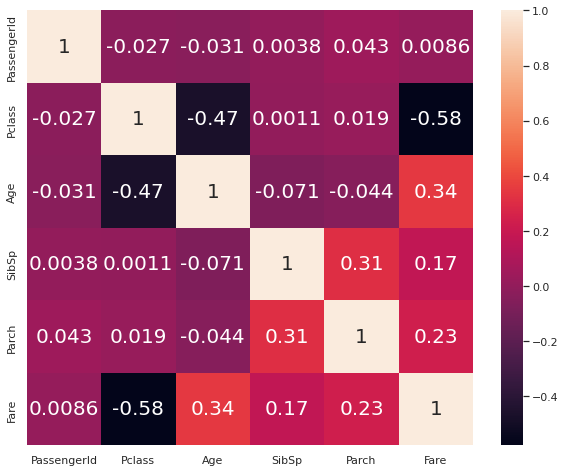

```python
sns.heatmap(actual_survivors.corr(),annot=True)
```

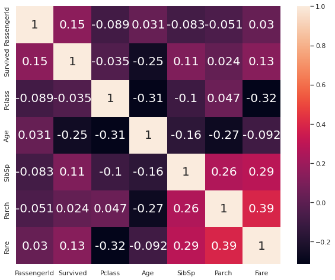

```python
sns.heatmap(survivor_data.corr(),annot=True)
```

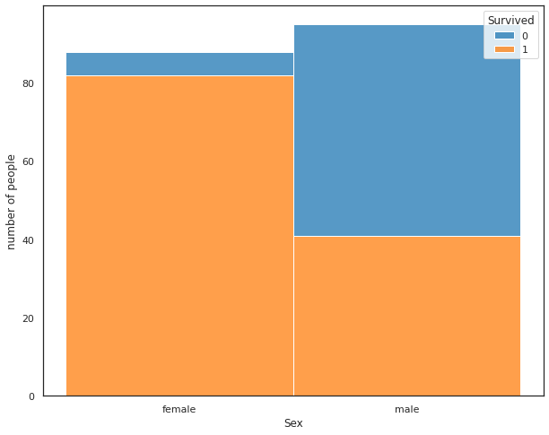

```python
#IMmprove correlation features of gender
sns.histplot(data=survivor_data, x='Sex', hue='Survived',multiple="stack")
plt.xlabel('Sex')
plt.ylabel("number of people")
plt.show()
```

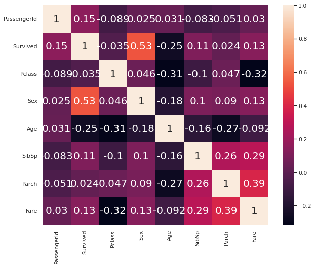

```python
for data in [survivor_data,actual_survivors]:

    data.Sex.replace('female',1,inplace=True)
    data.Sex.replace('male',0,inplace=True)

sns.heatmap(survivor_data.corr(),annot=True)
```

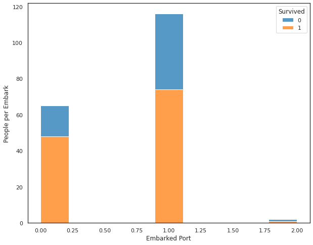

```python
for data in [survivor_data,actual_survivors]:
    data.Embarked.replace( 'C',0,inplace=True)
    data.Embarked.replace( 'S',1,inplace=True)
    data.Embarked.replace( 'Q',2,inplace=True)
    data.Embarked.fillna(value=data.Embarked.mode()[0], inplace=True)

sns.histplot(data=survivor_data, x='Embarked', hue='Survived',multiple="stack")
plt.ylabel("People per Embark")
plt.xlabel('Embarked Port')
plt.show()
```

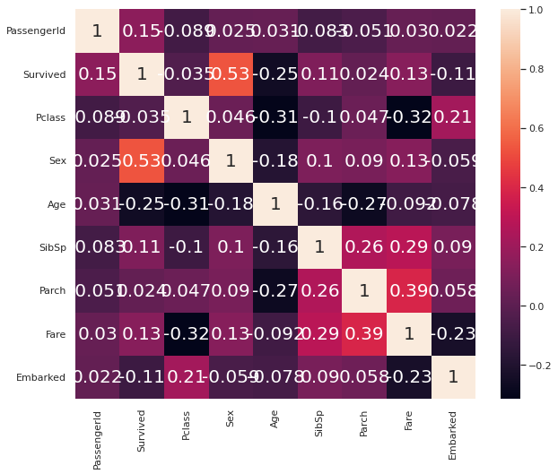

```python
sns.heatmap(survivor_data.corr(),annot=True)
```

```python
import warnings
warnings.filterwarnings("ignore")

Logistic_Regression()
```

```
Random error : 0.30434782608695654
Survivor error : 0.2608695652173913
```

```python
print("The two Logistic Regression Models accuracy : ")
print("")
print("Randomised feature model: " + str((1-accuracy[0])*100) +"%")
print("Grid feature model: " + str((1-accuracy[1])*100))
```

```
The two Logistic Regression Models accuracy :

Randomised feature model: 69.56521739130434%
Grid feature model: 73.91304347826086
```

[figure not shown]

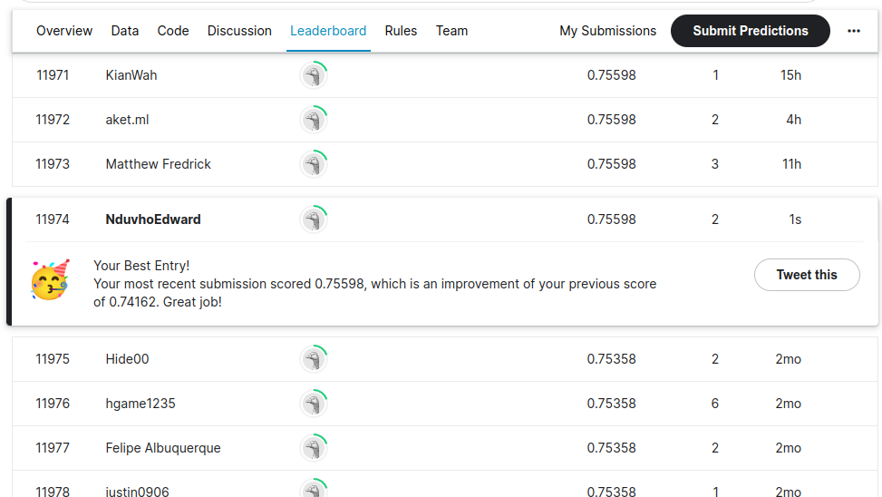

Work Distribution: Nduvho Ramashia (1490804) worked on the K-Nearest Neighbors (KNN) and Naiive Bayes Classifier (NBC) group, and Muchaveleli Manjate (1653288) worked on the Multi-layer perceptron (MLP) or Logistic Regression

Motivations

- https://triangleinequality.wordpress.com/2013/09/08/basic-feature-engineering-with-the-titanic-data/
- https://www.kaggle.com/code/kenjee/titanic-project-example/notebook